# Implementando ICs

Nazareno

## Os dados

```r
lastfm = read_csv(here::here("data/experimento-lastfm.csv"),
                  col_types = cols(.default = col_double(),
                                   user = col_character()))
glimpse(lastfm)
```

```
## Observations: 11,989
## Variables: 15
## $ user           <chr> "00blixt", "0ctane", "0sebastian0", "0xkirill", "…
## $ ecletic        <dbl> 1159.4960, 3439.8373, 1611.4464, 697.0974, 1660.1…
## $ clusters_total <dbl> 37, 155, 68, 37, 72, 93, 163, 150, 88, 132, 130, …
## $ clusters       <dbl> 19, 57, 25, 13, 31, 37, 64, 59, 27, 58, 62, 12, 3…
## $ media_pop      <dbl> 5.536362, 4.726167, 5.804086, 4.997963, 5.800357,…
## $ mediana_pop    <dbl> 5.660406, 4.730935, 5.896073, 5.214290, 5.865121,…
## $ dp_pop         <dbl> 0.6852190, 0.8819529, 0.6167104, 0.8685811, 0.544…
## $ news           <dbl> 38, 32, 24, 36, 28, 25, 30, 28, 14, 22, 27, 21, 2…
## $ news_total     <dbl> 38, 32, 24, 36, 28, 25, 30, 28, 14, 22, 27, 21, 2…
## $ old            <dbl> 116, 130, 10, 46, 128, 95, 228, 53, 46, 118, 90, …
## $ old_total      <dbl> 119, 141, 13, 71, 133, 167, 256, 63, 52, 125, 102…
## $ count_sim      <dbl> 0.155514371, 0.074823398, -0.123188406, 0.0841938…
## $ tempo_sim      <dbl> 0.208395596, -0.020325875, -0.043478261, -0.00160…
## $ count_pop      <dbl> 0.26923104, 0.13144651, -0.16666667, 0.09372521, …
## $ tempo_pop      <dbl> 0.08303680, -0.14228113, -0.11594203, 0.13012993,…
```

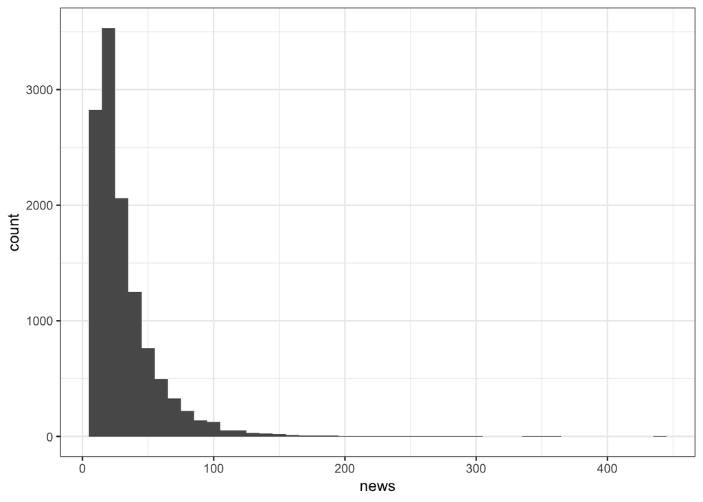

```r
lastfm = select(lastfm, news, ecletic)

lastfm %>% ggplot(aes(news)) + geom_histogram(binwidth = 10)
```

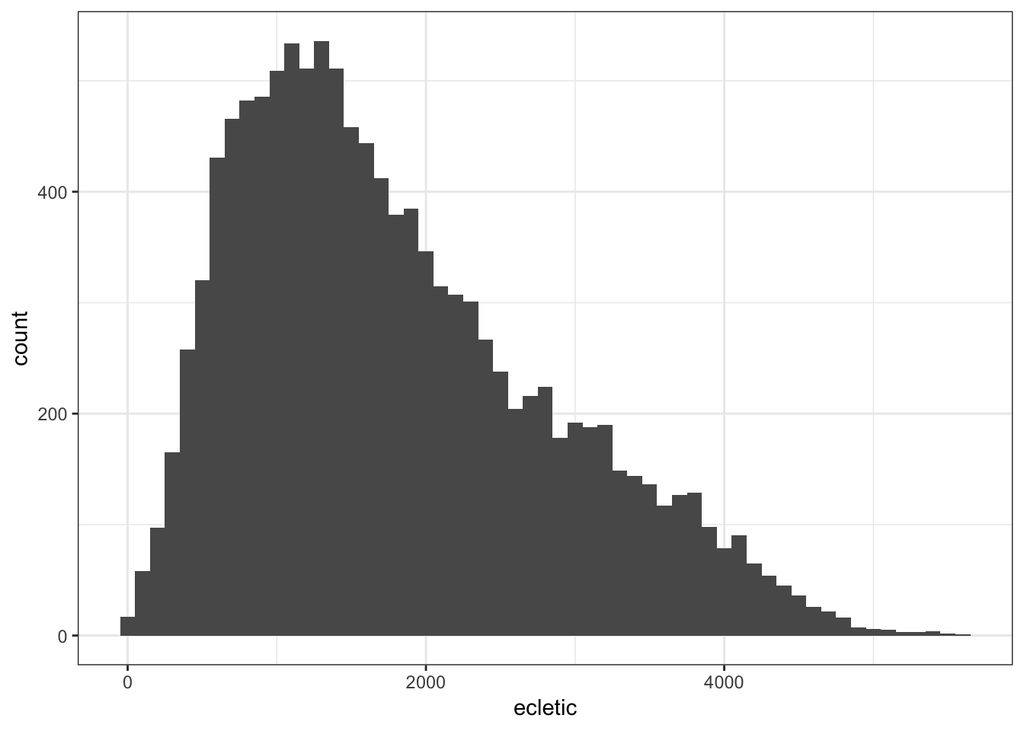

```r
lastfm %>% ggplot(aes(ecletic)) + geom_histogram(binwidth = 100)
```

## Amostra e visões a partir dela

Imagine por agora que os dados que temos do Last.fm são completos. Que são a população inteira de usuários. Se o que nos interessa por exemplo é a média dessa população, ela é exatamente:

```r
theta = lastfm %>%
  pull(news) %>%
  mean() # theta: média calculada com todos os dados

theta
```

```
## [1] 32.51756
```

Como seria nossa visão dos dados se tivéssemos apenas uma amostra dos dados? `sample(x, n)` faz uma amostra aleatórioa de `n` elementos tirados do vetor `x`:

Se calcularmos a média do números de novos artistas escutados para três amostras de 100 elementos, teremos 3 resultados diferentes (3 $\hat{\theta}$ diferentes):

```r
lastfm %>% pull(news) %>% sample(size = 100) %>% mean()
```

```
## [1] 32.64
```

```r
lastfm %>% pull(news) %>% sample(100) %>% mean()
```

```
## [1] 30.59
```

```r
lastfm %>% pull(news) %>% sample(100) %>% mean()
```

```
## [1] 32.06
```

Se fizermos isso muitas vezes vemos como essa variação de $\hat{\theta}$ acontece. A distribuição dos valores de uma estatística em diferentes amostras de uma população se chama **distribuição amostral** da estatística.

```r
set.seed(1)

amostra_calcula_theta_c = function(df, n = 100) {
  df %>%
    pull(news) %>%
    sample(n) %>%
    mean()
}

amostras = tibble(amostra = 1:1000) %>% # faremos 1000 vezes
  mutate(theta_c = map_dbl(amostra, ~ amostra_calcula_theta_c(lastfm)))

amostras
```

| amostra | theta_c |
| --- | --- |
| 1 | 31.52 |
| 2 | 32.65 |
| 3 | 31.77 |
| 4 | 30.54 |
| 5 | 36.21 |
| 6 | 32.85 |
| 7 | 33.37 |
| 8 | 27.52 |
| 9 | 30.86 |
| 10 | 29.30 |

[output cut: 990 more lines]

Podemos ver também qual a distribuição do **erro amostral**:

```r
amostras = amostras %>%
  mutate(erro = theta_c - theta)

amostras
```

| amostra | theta_c | erro |
| --- | --- | --- |
| 1 | 31.52 | -0.997557761 |
| 2 | 32.65 | 0.132442239 |
| 3 | 31.77 | -0.747557761 |
| 4 | 30.54 | -1.977557761 |
| 5 | 36.21 | 3.692442239 |
| 6 | 32.85 | 0.332442239 |
| 7 | 33.37 | 0.852442239 |
| 8 | 27.52 | -4.997557761 |
| 9 | 30.86 | -1.657557761 |
| 10 | 29.30 | -3.217557761 |

[output cut: 990 more lines]

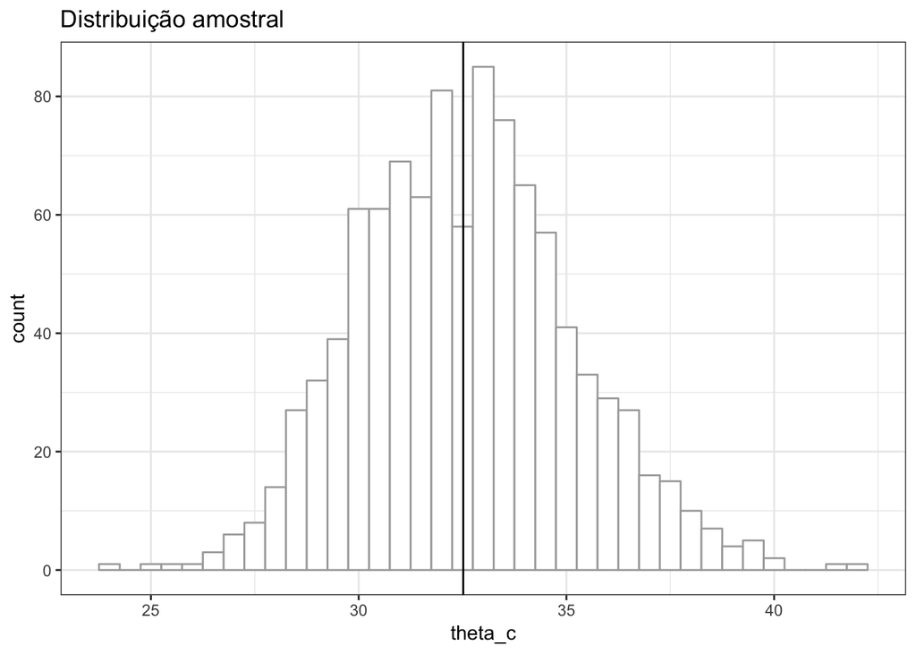

```r
amostras %>%
  ggplot(aes(theta_c)) +
  geom_histogram(binwidth = .5,
                 fill = "white",
                 colour = "darkgrey") +
  geom_vline(xintercept = theta) +
  labs(title = "Distribuição amostral")
```

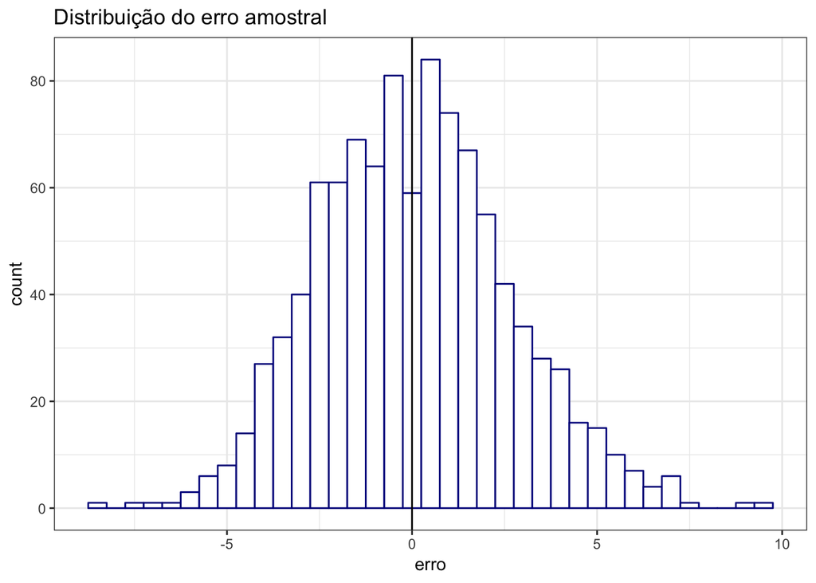

```r
amostras %>%
  ggplot(aes(erro)) +
  geom_histogram(binwidth = .5,
                 fill = "white",
                 colour = "darkblue") +
  geom_vline(xintercept = 0) +
  labs(title = "Distribuição do erro amostral")
```

Veja que conhecendo a distribuição de $\delta = \hat{\theta} - \theta$ nós conhecemos como as visões de $\theta$ a partir de amostras variam. Com isso nós sabemos quão longe $\hat{\theta}$ geralmente está de $\theta$ **e vice-versa.**

Na prática: usando a distribuição nós conseguimos encontrar 2 valores de $\delta = \hat{\theta} - \theta$ entre os quais os quais $\hat{\theta} - \theta$ está 90% do tempo. Basta encontrar o 5 e o 95 percentis. Esses são os dois valores mais próximos que contém 90% das observações.

```r
intervalo = amostras %>%
  summarise(erro_i = quantile(erro, .05),
            erro_s = quantile(erro, .95))

intervalo
```

| erro_i | erro_s |
| --- | --- |
| -3.948058 | 4.494942 |

Esse esse intervalo ao redor de $\theta$ é o intervalo onde $\hat{\theta}$ está 90% do tempo:

```r
intervalo = intervalo %>%
  mutate(valor_i = theta + erro_i,
         valor_s = theta + erro_s)

intervalo
```

| erro_i | erro_s | valor_i | valor_s |
| --- | --- | --- | --- |
| -3.948058 | 4.494942 | 28.5695 | 37.0125 |

```r
amostras %>%
  mutate(no_intervalo = theta_c >= intervalo$valor_i &
           theta_c <= intervalo$valor_s) %>%
  summarise(sum(no_intervalo) / n())
```

| sum(no_intervalo)/n() |
| --- |
| 0.9 |

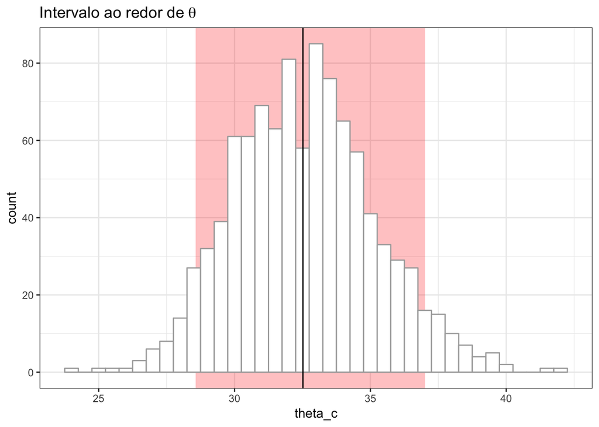

```r
ggplot() +
  geom_rect(
    data = intervalo,
    aes(xmin = valor_i, xmax = valor_s),
    ymin = -Inf,
    ymax = Inf,
    fill = "red",
    alpha = .25
  ) +
  geom_histogram(
    data = amostras,
    aes(x = theta_c),
    binwidth = .5,
    fill = "white",
    colour = "darkgrey"
  ) +
  geom_vline(xintercept = theta) +
  labs(title = expression("Intervalo ao redor de" ~ theta))
```

#### Se sabemos a distância de A pra B, sabemos de B pra A

```r
ic_amostras = amostras %>%
  mutate(intervalo_i = theta_c + intervalo$erro_i,
         intervalo_s = theta_c + intervalo$erro_s) %>%
  mutate(contem_theta = theta >= intervalo_i & theta <= intervalo_s)

ic_amostras %>%
  summarise(cobertura = sum(contem_theta) / n())
```

| cobertura |
| --- |
| 0.898 |

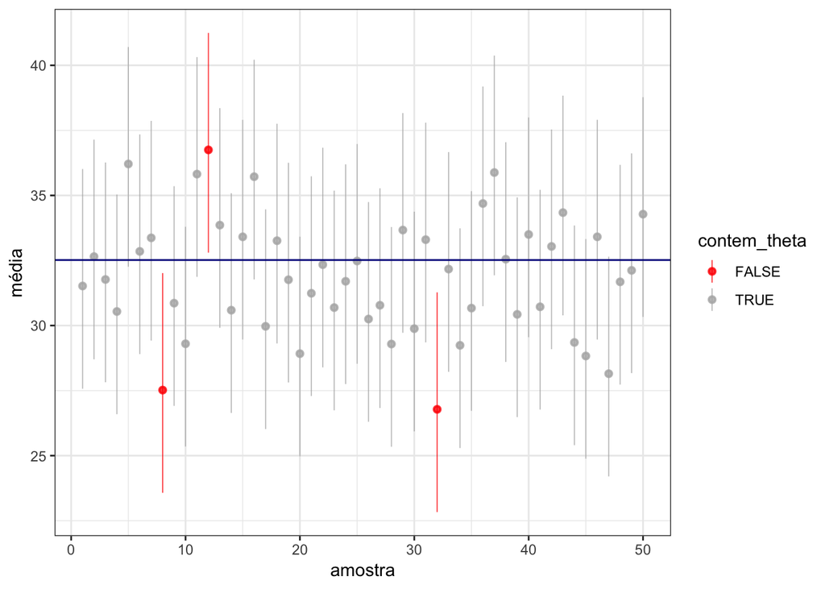

```r
ic_amostras %>%
  slice(1:50) %>%
  ggplot(aes(
    x = amostra,
    y = theta_c,
    ymin = intervalo_i,
    ymax = intervalo_s,
    color = contem_theta
  )) +
  geom_pointrange(alpha = .8, size = .3) +
  geom_hline(yintercept = theta, color = "dark blue") +
  labs(x = "amostra",
       y = "média") +
  scale_color_manual(values = c("red", "grey70"))
```

### Podia ser outra estatística

A mesma lógica vale para outras estatísticas além da média. O código abaixo analisa a distribuição dos valores observados em amostras a partir das quais calculamos a *mediana*. Altere o código para usar outra estatística: (dica: max e min não funcionam.)

```r
funcao_theta = function(df) {
  df %>%
    pull(news) %>%
    median()
}

theta = funcao_theta(lastfm)

amostras = tibble(amostra = 1:1000) %>% # faremos 1000 vezes
  mutate(theta_c = map_dbl(amostra, ~ lastfm %>%
                                       sample_n(100) %>%
                                       funcao_theta()))

amostras
```

| amostra | theta_c |
| --- | --- |
| 1 | 22.5 |
| 2 | 24.0 |
| 3 | 21.0 |
| 4 | 25.0 |
| 5 | 24.0 |
| 6 | 23.5 |
| 7 | 22.5 |
| 8 | 22.5 |
| 9 | 26.0 |
| 10 | 21.0 |

[output cut: 990 more lines]

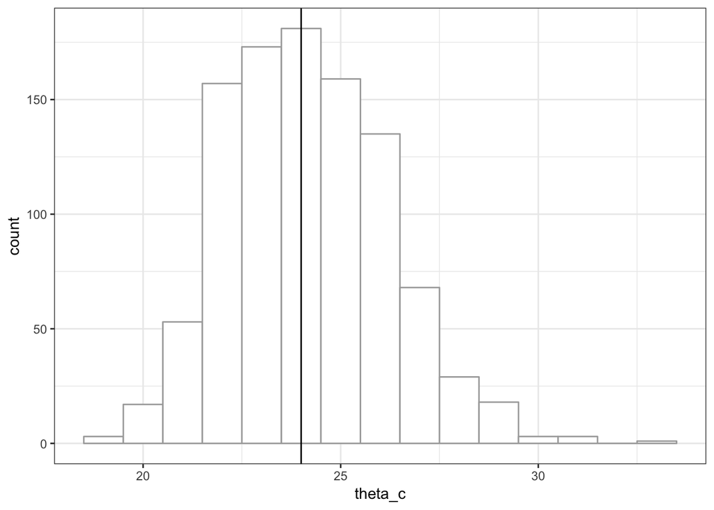

```r
amostras %>%
  ggplot(aes(theta_c)) +
  geom_histogram(binwidth = 1, fill = "white", colour = "darkgrey") +
  geom_vline(xintercept = theta)
```

### Efeito do tamanho da amostra

E se o tamanho da amostra (*n*) fosse muito menor?

```r
amostras = data.frame(amostra = 1:1000) %>% # faremos 1000 vezes
  mutate(media = map_dbl(amostra, ~ lastfm %>%
                                      pull(news) %>%
                                      sample(10) %>%
                                      mean()))

amostras
```

| amostra | media |
| --- | --- |
| 1 | 32.0 |
| 2 | 22.2 |
| 3 | 21.8 |
| 4 | 31.1 |
| 5 | 26.8 |
| 6 | 29.3 |
| 7 | 24.8 |
| 8 | 30.0 |
| 9 | 29.5 |
| 10 | 60.9 |

[output cut: 990 more lines]

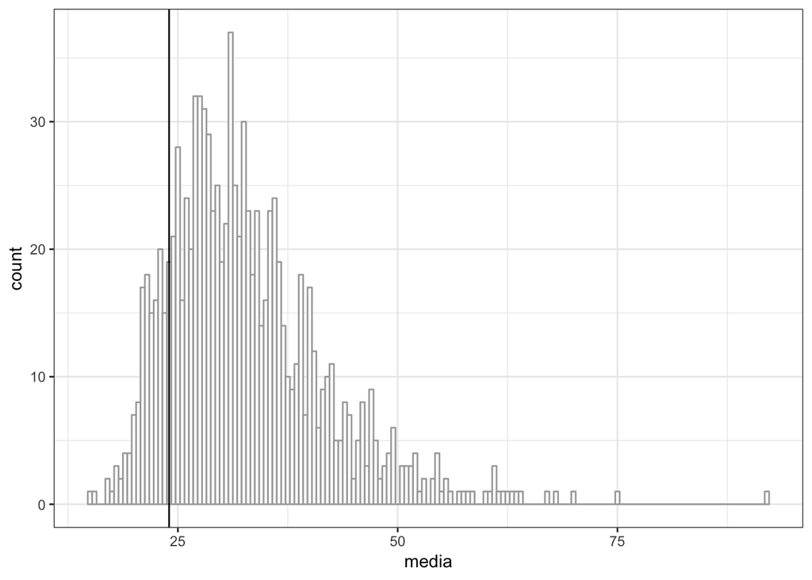

```r
amostras %>%
  ggplot(aes(media)) +
  geom_histogram(binwidth = .5, fill = "white", colour = "darkgrey") +
  geom_vline(xintercept = theta)
```

## E como conseguimos a distribuição amostral?

Espero que até agora tenha ficado claro que tendo a distribuição dos valores de uma estatística $\hat{\theta}$ a partir de amostras (a *distribuição amostral*) e do valor de $\hat{\theta}$ conseguimos estimar um intervalo com um método que acerta com uma cobertura conhecida. Conseguimos estimar uma margem de erro a partir de nosso $\hat{\theta}$ com uma confiança conhecida.

### Só que…

Nós nunca temos várias amostras da população como nos exemplos até agora. Estamos aqui porque nós não temos a população, e todo o dado que temos forma **uma amostra**. Caso não tenha ficado claro: o exercício até agora foi *simular* o que aconteceria se tivéssemos várias amostras para fins pedagógicos.

### A ideia central que usaremos

Não temos a população, para estimar a variação na distribuição amostral. Mas temos algo que veio dessa população, que é a amostra. Em várias situações como essa, a Estatística contorna a falta da informação ideal usando a que temos e um método que funcione bem assim. A ideia principal que usaremos é uma técnica chamada *boostrapping* que funciona porque *usar a amostra como substituto da população e simular a amostragem através de reamostragem com reposição fornece uma estimativa precisa da variação na distribuição amostral*.

Pegando por partes:

- Consideramos a amostra $A$ que tem tamanho $n$ como sendo um substituto da população
- Repetimos $b$ vezes o seguinte processo: criamos uma amostra de tamanho $n$ obtendo elementos aleatoriamente de $A$, repondo cada elemento depois de cada sorteio.
- Calculamos a estatística que nos interessa (média, mediana, desvio padrão, o que for) para cada uma das $b$ amostras, gerando $b$ valores de $\hat{\theta}*$.

Como resultado, teremos uma distribuição de como $\hat{\theta}*$ varia.

O princípio do bootstrap diz que *a variação de $\hat{\theta}*$ nos bootstraps aproxima a variação de $\hat{\theta}$*.

Com isso, podemos usar a mesma lógica que usamos acima e construir um intervalo ao retor de $\hat{\theta}$ que contém $\theta$ com uma certa confiança.

## Aplicando bootstrapping

$P(\delta_{0.05} \le e_a - e_p \le \delta_{0.95} | e_p) = .9$. Manipulando, temos que $P(e_a - \delta_{0.05} \ge e_p \ge e_a - \delta_{0.95} | e_p) = .9$. Ou seja, o IC é $[e_a - \delta_{0.05}; e_a - \delta_{0.95}]$.

### Aplicando bootstrapping

```r
funcao_theta = function(df) {
  df %>%
    pull(news) %>%
    mean()
}

theta = funcao_theta(lastfm)

set.seed(1212)
amostra = lastfm %>%
  sample_n(200)

theta_c = funcao_theta(amostra)
```

```r
repeticoes = 4000 # pelo menos 2000, mas mais não faz mal.

um_bootstrap <- function(x){
  news = x %>% pull(news)
  boot_x <- sample(news,           # amostre dos dados
                   size = NROW(news), # tamanho igual ao recebido
                   replace = TRUE) # aqui é o bootstrap
  return(mean(boot_x))
}

set.seed(1212)

# A REAMOSTRAGEM
reamostragens = tibble(i = 1:repeticoes) %>%
  mutate(theta_c_s = map_dbl(i, ~ um_bootstrap(amostra)))

reamostragens
```

| i | theta_c_s |
| --- | --- |
| 1 | 31.870 |
| 2 | 33.735 |
| 3 | 32.835 |
| 4 | 34.055 |
| 5 | 33.570 |
| 6 | 31.145 |
| 7 | 34.075 |
| 8 | 33.575 |
| 9 | 31.455 |
| 10 | 33.945 |

[output cut: 3990 more lines]

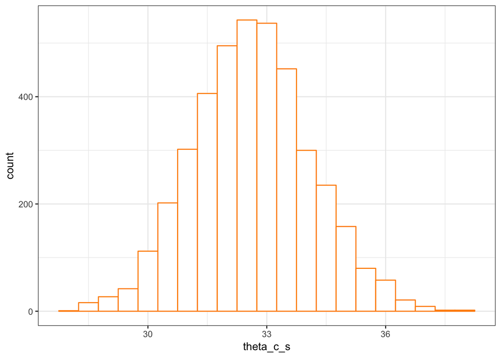

```r
reamostragens %>%
  ggplot(aes(x = theta_c_s)) +
  geom_histogram(binwidth = .5,
                 colour = "darkorange",
                 fill = "white")
```

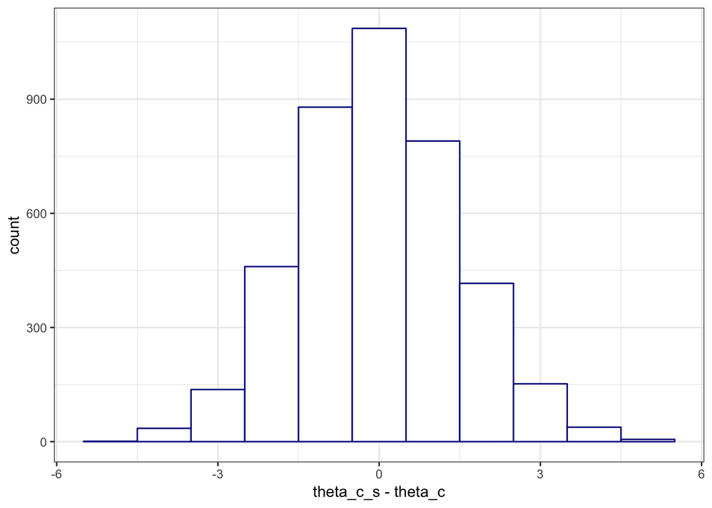

```r
reamostragens %>%
  ggplot(aes(x = theta_c_s - theta_c)) +
  geom_histogram(binwidth = 1,
                 colour = "darkblue",
                 fill = "white")
```